# Boosting Implementation Scratch(Decision Tree Update)

```python
import pandas as pd
import numpy as np
import pdb
import math
from math import exp
```

```python
loans = pd.read_csv('lending-club-data.csv')
```

```python
features = ['grade',              # grade of the loan
            'term',               # the term of the loan
            'home_ownership',     # home ownership status: own, mortgage or rent
            'emp_length',         # number of years of employment
           ]
loans['safe_loans'] = loans['bad_loans'].apply(lambda x : +1 if x==0 else -1)
loans.drop(['bad_loans'], inplace = True, axis = 1)
target = 'safe_loans'
loans = loans[features + [target]]
```

```python
onehot_encoded_loans = pd.get_dummies(loans)
```

```python
onehot_encoded_loans.iloc[1]
```

```
safe_loans                -1
grade_A                    0
grade_B                    0
grade_C                    1
grade_D                    0
grade_E                    0
grade_F                    0
grade_G                    0
term_ 36 months            0
term_ 60 months            1
home_ownership_MORTGAGE    0
home_ownership_OTHER       0
home_ownership_OWN         0
home_ownership_RENT        1
emp_length_1 year          0
emp_length_10+ years       0
emp_length_2 years         0
emp_length_3 years         0
emp_length_4 years         0
emp_length_5 years         0
emp_length_6 years         0
emp_length_7 years         0
emp_length_8 years         0
emp_length_9 years         0
emp_length_< 1 year        1
emp_length_n/a             0
Name: 1, dtype: float64
```

```python
import json
with open ('train-idx.json') as data_files:
    train_idx = json.load(data_files)
with open ('test_idx.json') as data_files:
    test_idx = json.load(data_files)
```

```python
train_data = onehot_encoded_loans.iloc[train_idx]
test_data = onehot_encoded_loans.iloc[test_idx]
#*****Really Important****
#Fix the features
features = list(train_data.columns.values)
features.remove('safe_loans')
target = 'safe_loans'
```

The function intermediate_node_weighted_mistakes should first compute two weights:

WM(−1): weight of mistakes when all predictions are ŷ_i = −1 i.e. WM(α,−1)  
WM(+1): weight of mistakes when all predictions are ŷ_i = +1 i.e. WM(α,+1)  
where −1 and +1 are vectors where all values are -1 and +1 respectively.

After computing WM(−1) and WM(+1), the function intermediate_node_weighted_mistakes should return the lower of the two weights of mistakes, along with the class associated with that weight.

```python
def intermediate_node_weighted_mistakes(labels_in_node, data_weights):
    # Sum the weights of all entries with label +1
    total_weight_positive =  sum(data_weights[np.where(labels_in_node == 1)])

    # Weight of mistakes for predicting all -1's is equal to the sum above
    ### YOUR CODE HERE
    weighted_mistakes_all_negative = total_weight_positive
    #print "weighted_mistakes_all_negative : ", weighted_mistakes_all_negative

    # Sum the weights of all entries with label -1
    ### YOUR CODE HERE
    total_weight_negative =  sum(data_weights[np.where(labels_in_node == -1)])

    # Weight of mistakes for predicting all +1's is equal to the sum above
    ### YOUR CODE HERE
    weighted_mistakes_all_positive = total_weight_negative
    #print "weighted_mistakes_all_positive :", weighted_mistakes_all_positive

    # Return the tuple (weight, class_label) representing the lower of the two weights
    #    class_label should be an integer of value +1 or -1.
    # If the two weights are identical, return (weighted_mistakes_all_positive,+1)
    ### YOUR CODE HERE
    if weighted_mistakes_all_positive <= weighted_mistakes_all_negative:
        weight = weighted_mistakes_all_positive
        class_label = +1
    else:
        weight = weighted_mistakes_all_negative
        class_label = -1
    return (weight, class_label)
```

Function to pick best feature to split on

1. We continue modifying our decision tree code from the earlier assignment to incorporate weighting of individual data points. The next step is to pick the best feature to split on.

The best_splitting_feature function is similar to the one from the earlier assignment with two minor modifications:

The function best_splitting_feature should now accept an extra parameter data_weights to take account of weights of data points.  
Instead of computing the number of mistakes in the left and right side of the split, we compute the weight of mistakes for both sides, add up the two weights, and divide it by the total weight of the data.

```python
# If the data is identical in each feature, this function should return None
def best_splitting_feature(data, features, target, data_weights):
    # These variables will keep track of the best feature and the corresponding error
    best_feature = None
    best_error = float('+inf')
    num_points = float(len(data))
    # Loop through each feature to consider splitting on that feature
    for feature in features:

        #print "data shape : ", data.shape
        #print "data weights shape : ", data_weights.shape

        # The left split will have all data points where the feature value is 0
        # The right split will have all data points where the feature value is 1
        left_split = data[data[feature] == 0]
        right_split = data[data[feature] == 1]
        # Apply the same filtering to data_weights to create left_data_weights, right_data_weights
        ## YOUR CODE HERE
        left_data_weights = data_weights[np.where(data[feature] == 0)]
        right_data_weights = data_weights[np.where(data[feature] == 1)]
        #print "split : ", left_split.shape
        #print "weights : ", left_data_weights.shape

        # DIFFERENT HERE
        # Calculate the weight of mistakes for left and right sides
        ## YOUR CODE HERE
        left_weighted_mistakes, left_class = intermediate_node_weighted_mistakes(left_split[target], left_data_weights)
        right_weighted_mistakes, right_class = intermediate_node_weighted_mistakes(right_split[target], right_data_weights)
        #print "%s : LWM : %s, RWM : %s" %(feature, left_weighted_mistakes, right_weighted_mistakes)

        # DIFFERENT HERE
        # Compute weighted error by computing
        #  ( [weight of mistakes (left)] + [weight of mistakes (right)] ) / [total weight of all data points]
        ## YOUR CODE HERE
        error = (left_weighted_mistakes + right_weighted_mistakes) / float(sum(data_weights))
        # If this is the best error we have found so far, store the feature and the error
        if error < best_error:
            best_feature = feature
            best_error = error

    # Return the best feature we found
    return best_feature
```

```python
def create_leaf(target_values, data_weights):

    # Create a leaf node
    leaf = {'splitting_feature' : None,
            'is_leaf': True}

    # Computed weight of mistakes.
    # Store the predicted class (1 or -1) in leaf['prediction']
    weighted_error, best_class = intermediate_node_weighted_mistakes(target_values, data_weights)
    leaf['prediction'] = best_class

    return leaf
```

Now write a function that learns a weighted decision tree recursively and implements 3 stopping conditions:

All data points in a node are from the same class.  
No more features to split on.  
Stop growing the tree when the tree depth reaches max_depth.

```python
def weighted_decision_tree_create(data, features, target, data_weights, current_depth = 1, max_depth = 10):
    remaining_features = features[:] # Make a copy of the features.
    target_values = data[target]
    print "--------------------------------------------------------------------"
    print "Subtree, depth = %s (%s data points)." % (current_depth, len(target_values))

    # Stopping condition 1. Error is 0.
    if intermediate_node_weighted_mistakes(target_values, data_weights)[0] <= 1e-15:
        print "Stopping condition 1 reached."
        return create_leaf(target_values, data_weights)

    # Stopping condition 2. No more features.
    if remaining_features == []:
        print "Stopping condition 2 reached."
        return create_leaf(target_values, data_weights)

    # Additional stopping condition (limit tree depth)
    if current_depth > max_depth:
        print "Reached maximum depth. Stopping for now."
        return create_leaf(target_values, data_weights)

    # If all the datapoints are the same, splitting_feature will be None. Create a leaf
    splitting_feature = best_splitting_feature(data, remaining_features, target, data_weights)
    #print "Splitting feature : ", splitting_feature
    remaining_features.remove(splitting_feature)
    #print "Remaining_featrues :", remaining_features

    left_split = data[data[splitting_feature] == 0]
    right_split = data[data[splitting_feature] == 1]

    left_data_weights = data_weights[np.where(data[splitting_feature] == 0)]
    right_data_weights = data_weights[np.where(data[splitting_feature] == 1)]

    print "Split on feature %s. (left:%s, right:%s)" % (\
              splitting_feature, len(left_split), len(right_split))

    # Create a leaf node if the split is "perfect"
    if len(left_split) == len(data):
        print "Creating leaf node."
        return create_leaf(left_split[target], data_weights)
    if len(right_split) == len(data):
        print "Creating leaf node."
        return create_leaf(right_split[target], data_weights)
    # Repeat (recurse) on left and right subtrees
    left_tree = weighted_decision_tree_create(
        left_split, remaining_features, target, left_data_weights, current_depth + 1, max_depth)
    right_tree = weighted_decision_tree_create(
        right_split, remaining_features, target, right_data_weights, current_depth + 1, max_depth)

    return {'is_leaf'          : False,
            'prediction'       : None,
            'splitting_feature': splitting_feature,
            'left'             : left_tree,
            'right'            : right_tree}
```

write a recursive function to count the nodes in your tree. The function should be analogous to

```python
def count_nodes(tree):
    if tree['is_leaf']:
        return 1
    return 1 + count_nodes(tree['left']) + count_nodes(tree['right'])
```

To make a single prediction, we must start at the root and traverse down the decision tree in recursive fashion. Write a function classify that makes a single prediction.

```python
def classify(tree, x, annotate = False):
    # If the node is a leaf node.
    if tree['is_leaf']:
        if annotate:
            print "At leaf, predicting %s" % tree['prediction']
        return tree['prediction']
    else:
        # Split on feature.
        split_feature_value = x[tree['splitting_feature']]
        if annotate:
            print "Split on %s = %s" % (tree['splitting_feature'], split_feature_value)
        if split_feature_value == 0:
            return classify(tree['left'], x, annotate)
        else:
            return classify(tree['right'], x, annotate)
```

```python
def evaluate_classification_error(tree, data):
    # Apply the classify(tree, x) to each row in your data
    prediction = data.apply(lambda x: classify(tree, x, annotate=False), axis = 1 )
    #Dont forget to put "axis"

    # Once you've made the predictions, calculate the classification error
    return (prediction != data[target]).sum() / float(len(data))
```

To build intuition on how weighted data points affect the tree being built, consider the following:

Suppose we only care about making good predictions for the first 10 and last 10 items in train_data, we assign weights:

1 to the last 10 items  
1 to the first 10 items  
and 0 to the rest.  
Let us fit a weighted decision tree with max_depth = 2. Then compute the classification error on the subset_20, i.e. the subset of data points whose weight is 1 (namely the first and last 10 data points).

```python
# Assign weights
example_data_weights = np.array([1.] * 10 + [0.]*(len(train_data) - 20) + [1.] * 10)
np.where(example_data_weights == 1)
```

```
(array([    0,     1,     2,     3,     4,     5,     6,     7,     8,
            9, 37214, 37215, 37216, 37217, 37218, 37219, 37220, 37221,
        37222, 37223]),)
```

```python
# Train a weighted decision tree model.
small_data_decision_tree_subset_20 = weighted_decision_tree_create(train_data, features, target,
                         example_data_weights, max_depth=2)
```

```
--------------------------------------------------------------------
Subtree, depth = 1 (37224 data points).
Split on feature home_ownership_RENT. (left:20514, right:16710)
--------------------------------------------------------------------
Subtree, depth = 2 (20514 data points).
Split on feature grade_F. (left:19613, right:901)
--------------------------------------------------------------------
Subtree, depth = 3 (19613 data points).
Reached maximum depth. Stopping for now.
--------------------------------------------------------------------
Subtree, depth = 3 (901 data points).
Stopping condition 1 reached.
--------------------------------------------------------------------
Subtree, depth = 2 (16710 data points).
Split on feature grade_D. (left:13315, right:3395)
--------------------------------------------------------------------
Subtree, depth = 3 (13315 data points).
Stopping condition 1 reached.
--------------------------------------------------------------------
Subtree, depth = 3 (3395 data points).
Stopping condition 1 reached.
```

```python
print count_nodes(small_data_decision_tree_subset_20)
```

```
7
```

```python
evaluate_classification_error(small_data_decision_tree_subset_20, train_data)
```

```
0.48124865678057166
```

```python
subset_20 = train_data.iloc[np.where(example_data_weights == 1)]
evaluate_classification_error(small_data_decision_tree_subset_20, subset_20)
```

```
0.050000000000000003
```

Now that we have a weighted decision tree working, it takes only a bit of work to implement Adaboost. For the sake of simplicity, let us stick with decision tree stumps by training trees with max_depth=1.

Recall from the lecture the procedure for Adaboost:

- Start with unweighted data with α_j = 1
- For t=1,...,T:

Learn f_t(x) with data weights α_j  
Compute coefficient ŵ_t:

Re-compute weights α_j

Normalize weights α_j

Now write your own Adaboost function. The function accepts 4 parameters:

data: a data frame with binary features  
features: list of feature names  
target: name of target column  
num_tree_stumps: number of tree stumps to train for the ensemble  
The function should return the list of tree stumps, along with the list of corresponding tree stump weights.

```python
def adaboost_with_tree_stumps(data, features, target, num_tree_stumps):
    # start with unweighted data
    alpha = np.array([1.]*len(data))
    weights = []
    tree_stumps = []
    target_values = data[target]

    for t in xrange(num_tree_stumps):
        #pdb.set_trace()
        print '====================================================='
        print 'Adaboost Iteration %d' % t
        print '====================================================='
        # Learn a weighted decision tree stump. Use max_depth=1
        tree_stump = weighted_decision_tree_create(data, features, target, data_weights=alpha, max_depth=1)
        #since we are using stump, max_depth is equal 1
        tree_stumps.append(tree_stump)

        # Make predictions
        predictions = data.apply(lambda x: classify(tree_stump, x), axis = 1)

        # Produce a Boolean array indicating whether
        # each data point was correctly classified
        is_correct = predictions == target_values
        is_wrong   = predictions != target_values
        # Compute weighted error
        # YOUR CODE HERE
        weighted_error = sum(alpha[np.where(predictions != target_values)]) / float(sum(alpha))
        #print "1.weighted_error :", weighted_error
        # Compute model coefficient using weighted error
        # YOUR CODE HERE
        weight = 0.5 * np.log( (1-weighted_error)/float(weighted_error))
        #print "2.weight :", weight
        weights.append(weight)
        # Adjust weights on data point
        adjustment = is_correct.apply(lambda is_correct : exp(-weight) if is_correct else exp(weight))
        #print "3.adjustment : ", adjustment
        # Scale alpha by multiplying by adjustment
        # Then normalize data points weights
        ## YOUR CODE HERE
        alpha = alpha * adjustment
        alpha_normal = alpha / float(sum(alpha))
        alpha = alpha_normal.values       #chage daya type

    return weights, tree_stumps
```

Reminders

Stump weights (ŵ) and data point weights (α) are two different concepts.  
Stump weights (ŵ) tell you how important each stump is while making predictions with the entire boosted ensemble.  
Data point weights (α) tell you how important each data point is while training a decision stump.

```python
boosted_10 = adaboost_with_tree_stumps(train_data, features, target, num_tree_stumps = 5)
```

```
=====================================================
Adaboost Iteration 0
=====================================================
--------------------------------------------------------------------
Subtree, depth = 1 (37224 data points).
Split on feature term_ 36 months. (left:9223, right:28001)
--------------------------------------------------------------------
Subtree, depth = 2 (9223 data points).
Reached maximum depth. Stopping for now.
--------------------------------------------------------------------
Subtree, depth = 2 (28001 data points).
Reached maximum depth. Stopping for now.
=====================================================
Adaboost Iteration 1
=====================================================
--------------------------------------------------------------------
Subtree, depth = 1 (37224 data points).
Split on feature grade_A. (left:32094, right:5130)
--------------------------------------------------------------------
Subtree, depth = 2 (32094 data points).
Reached maximum depth. Stopping for now.
--------------------------------------------------------------------
Subtree, depth = 2 (5130 data points).
Reached maximum depth. Stopping for now.
=====================================================
Adaboost Iteration 2
=====================================================
--------------------------------------------------------------------
Subtree, depth = 1 (37224 data points).
Split on feature grade_D. (left:30465, right:6759)
--------------------------------------------------------------------
Subtree, depth = 2 (30465 data points).
Reached maximum depth. Stopping for now.
--------------------------------------------------------------------
Subtree, depth = 2 (6759 data points).
Reached maximum depth. Stopping for now.
=====================================================
Adaboost Iteration 3
=====================================================
--------------------------------------------------------------------
Subtree, depth = 1 (37224 data points).
Split on feature home_ownership_MORTGAGE. (left:19846, right:17378)
--------------------------------------------------------------------
Subtree, depth = 2 (19846 data points).
Reached maximum depth. Stopping for now.
--------------------------------------------------------------------
Subtree, depth = 2 (17378 data points).
Reached maximum depth. Stopping for now.
=====================================================
Adaboost Iteration 4
=====================================================
--------------------------------------------------------------------
Subtree, depth = 1 (37224 data points).
Split on feature grade_B. (left:26858, right:10366)
--------------------------------------------------------------------
Subtree, depth = 2 (26858 data points).
Reached maximum depth. Stopping for now.
--------------------------------------------------------------------
Subtree, depth = 2 (10366 data points).
Reached maximum depth. Stopping for now.
```

Do the following things in a new function predict_adaboost:

Compute the predictions f_t(x) using the t-th decision tree  
Compute ŵ_t f_t(x) by multiplying the stump_weights with the predictions f_t(x) from the decision trees  
Sum the weighted predictions over each stump in the ensemble.

```python
def predict_adaboost(stump_weights, tree_stumps, data):
    scores = np.array([0.]*len(data))

    for i, tree_stump in enumerate(tree_stumps):
        predictions = data.apply(lambda x: classify(tree_stump, x), axis = 1)
        #print "predictions : ", predictions[0:5]
        weighted_predictions = predictions * stump_weights[i]
        #print "weighted_predictions : ", weighted_predictions[0:5]
        # Accumulate predictions on scaores array
        # YOUR CODE HERE
        scores = scores + weighted_predictions
        #print "scores : ", scores[0:5]

    return scores.apply(lambda score : +1 if score > 0 else -1)
```

```python
def calculate_accuracy(y_values, predictions):
    correct = sum(y_values == predictions)
    return correct / float(len(y_values))
```

```python
boost10_predict = predict_adaboost(boosted_10[0],boosted_10[1], train_data)
```

boosted_10[0] <- weights  
boosted_10[1] <- tree stumps

Computing training error at the end of each iteration

1. Let us compute the classification error on the train_data and see how it is reduced as trees are added.

For n = 1 to 30, do the following:

Make predictions on train_data using tree stumps 0, ..., n-1.  
Compute classification error for the predictions  
Record the classification error for that n.

```python
boosted_30 = adaboost_with_tree_stumps(train_data, features, target, num_tree_stumps = 30)
```

```
=====================================================
Adaboost Iteration 0
=====================================================
--------------------------------------------------------------------
Subtree, depth = 1 (37224 data points).
Split on feature term_ 36 months. (left:9223, right:28001)
--------------------------------------------------------------------
Subtree, depth = 2 (9223 data points).
Reached maximum depth. Stopping for now.
--------------------------------------------------------------------
Subtree, depth = 2 (28001 data points).
Reached maximum depth. Stopping for now.
=====================================================
Adaboost Iteration 1
=====================================================
--------------------------------------------------------------------
Subtree, depth = 1 (37224 data points).
Split on feature grade_A. (left:32094, right:5130)
--------------------------------------------------------------------
Subtree, depth = 2 (32094 data points).
Reached maximum depth. Stopping for now.
--------------------------------------------------------------------
Subtree, depth = 2 (5130 data points).
Reached maximum depth. Stopping for now.
=====================================================
Adaboost Iteration 2
=====================================================
--------------------------------------------------------------------
Subtree, depth = 1 (37224 data points).
Split on feature grade_D. (left:30465, right:6759)
--------------------------------------------------------------------
Subtree, depth = 2 (30465 data points).
Reached maximum depth. Stopping for now.
--------------------------------------------------------------------
Subtree, depth = 2 (6759 data points).
Reached maximum depth. Stopping for now.
=====================================================
Adaboost Iteration 3
=====================================================
--------------------------------------------------------------------
```

[output cut: 305 more lines]

```
--------------------------------------------------------------------
Subtree, depth = 2 (1443 data points).
Reached maximum depth. Stopping for now.
=====================================================
Adaboost Iteration 29
=====================================================
--------------------------------------------------------------------
Subtree, depth = 1 (37224 data points).
Split on feature grade_C. (left:27812, right:9412)
--------------------------------------------------------------------
Subtree, depth = 2 (27812 data points).
Reached maximum depth. Stopping for now.
--------------------------------------------------------------------
Subtree, depth = 2 (9412 data points).
Reached maximum depth. Stopping for now.
```

```python
error_all = []
stump_weights = boosted_30[0]
tree_stumps = boosted_30[1]

for n in xrange(1, 31):
    predictions = predict_adaboost(stump_weights[:n], tree_stumps[:n], train_data)
    error = 1.0 - calculate_accuracy(train_data[target], predictions)
    error_all.append(error)
    print "Iteration %s, training error = %s" % (n, error_all[n-1])
```

```
Iteration 1, training error = 0.421636578551
Iteration 2, training error = 0.433430045132
Iteration 3, training error = 0.400037610144
Iteration 4, training error = 0.400037610144
Iteration 5, training error = 0.384724908661
Iteration 6, training error = 0.384617451107
Iteration 7, training error = 0.382763808296
Iteration 8, training error = 0.384617451107
Iteration 9, training error = 0.382763808296
Iteration 10, training error = 0.384483129164
Iteration 11, training error = 0.382736943907
Iteration 12, training error = 0.381447453256
Iteration 13, training error = 0.381528046422
Iteration 14, training error = 0.380560928433
Iteration 15, training error = 0.380507199656
Iteration 16, training error = 0.378223726628
Iteration 17, training error = 0.378277455405
Iteration 18, training error = 0.378411777348
Iteration 19, training error = 0.378062540297
Iteration 20, training error = 0.378761014399
Iteration 21, training error = 0.379566946056
Iteration 22, training error = 0.378895336342
Iteration 23, training error = 0.378895336342
Iteration 24, training error = 0.378761014399
Iteration 25, training error = 0.378895336342
Iteration 26, training error = 0.378975929508
Iteration 27, training error = 0.379110251451
Iteration 28, training error = 0.378922200731
Iteration 29, training error = 0.379029658285
Iteration 30, training error = 0.378734150011
```

```python
test_error_all = []

for n in xrange(1, 31):
    predictions = predict_adaboost(stump_weights[:n], tree_stumps[:n], test_data)
    error = 1.0 - calculate_accuracy(test_data[target], predictions)
    test_error_all.append(error)
    print "Iteration %s, training error = %s" % (n, test_error_all[n-1])
```

```
Iteration 1, training error = 0.42330891857
Iteration 2, training error = 0.428479103835
Iteration 3, training error = 0.398104265403
Iteration 4, training error = 0.398104265403
Iteration 5, training error = 0.379900904782
Iteration 6, training error = 0.380008616975
Iteration 7, training error = 0.379254631624
Iteration 8, training error = 0.380008616975
Iteration 9, training error = 0.379254631624
Iteration 10, training error = 0.379685480396
Iteration 11, training error = 0.379254631624
Iteration 12, training error = 0.377962085308
Iteration 13, training error = 0.379254631624
Iteration 14, training error = 0.377854373115
Iteration 15, training error = 0.378500646273
Iteration 16, training error = 0.377854373115
Iteration 17, training error = 0.377962085308
Iteration 18, training error = 0.377854373115
Iteration 19, training error = 0.378177509694
Iteration 20, training error = 0.376884963378
Iteration 21, training error = 0.377531236536
Iteration 22, training error = 0.376777251185
Iteration 23, training error = 0.376777251185
Iteration 24, training error = 0.376884963378
Iteration 25, training error = 0.376777251185
Iteration 26, training error = 0.376561826799
Iteration 27, training error = 0.376454114606
Iteration 28, training error = 0.376992675571
Iteration 29, training error = 0.376777251185
Iteration 30, training error = 0.376777251185
```

```python
import matplotlib.pyplot as plt
%matplotlib inline
```

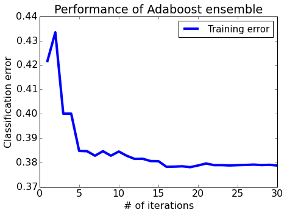

```python
plt.rcParams['figure.figsize'] = 7, 5
plt.plot(range(1,31), error_all, '-', linewidth=4.0, label='Training error')
plt.title('Performance of Adaboost ensemble')
plt.xlabel('# of iterations')
plt.ylabel('Classification error')
plt.legend(loc='best', prop={'size':15})

plt.rcParams.update({'font.size': 16})
```

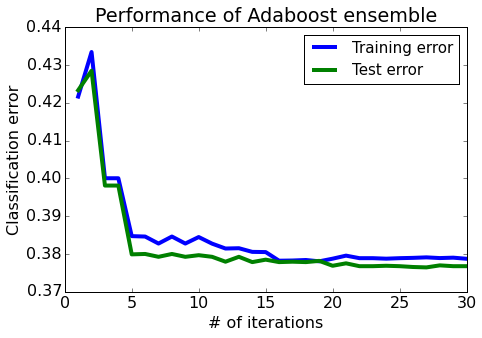

```python
plt.rcParams['figure.figsize'] = 7, 5
plt.plot(range(1,31), error_all, '-', linewidth=4.0, label='Training error')
plt.plot(range(1,31), test_error_all, '-', linewidth=4.0, label='Test error')

plt.title('Performance of Adaboost ensemble')
plt.xlabel('# of iterations')
plt.ylabel('Classification error')
plt.rcParams.update({'font.size': 16})
plt.legend(loc='best', prop={'size':15})
plt.tight_layout()
```